# Differential Expression Analysis: Ewing Sarcoma vs Liposarcoma

Musfirah

17-07-2026

## Abstract

This study performed differential expression analysis comparing **Ewing Sarcoma** (n=19) and **Liposarcoma** (n=33) samples from the GSE2553 dataset. A total of **1443 significant DEGs** were identified (padj < 0.05, |log2FC| > 1), including 780 upregulated and 663 downregulated genes. NKX2-2 was identified as a key Ewing Sarcoma biomarker.

## 1. Introduction

Soft tissue sarcomas represent a heterogeneous group of malignant tumors. Ewing Sarcoma is characterized by the EWS-FLI1 fusion gene and primarily affects children and young adults. Liposarcoma originates from adipose tissue and is the most common soft tissue sarcoma in adults. Understanding the molecular differences between these subtypes is crucial for developing targeted therapies.

## 2. Methods

### 2.1 Data Source

GSE2553 dataset was downloaded from NCBI GEO using GEOquery. Ewing Sarcoma (n=19) and Liposarcoma (n=33) samples were selected for comparison.

### 2.2 Differential Expression Analysis

DESeq2 R package was used for differential expression analysis. Genes with adjusted p-value < 0.05 and |log2 fold change| > 1 were considered significantly differentially expressed.

### 2.3 Pathway Enrichment

GO and KEGG pathway enrichment was performed using enrichR R package on top 50 upregulated genes.

## 3. Results

### 3.1 Overview of Differential Expression

| Metric | Value |
| --- | --- |
| Total genes analyzed | 9193 |
| Significant DEGs | 1443 |
| Upregulated in Ewing | 780 |
| Downregulated in Ewing | 663 |

### 3.2 Volcano Plot

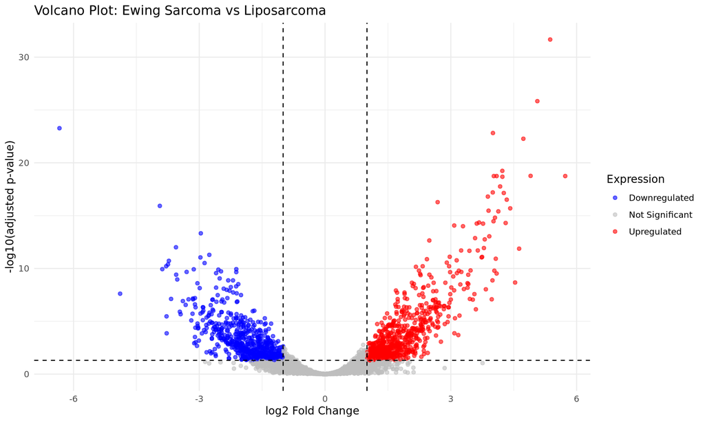

Figure 1: Volcano plot of differential expression

### 3.3 Top Differentially Expressed Genes

Table 1: Top 20 differentially expressed genes

| Gene | log2FoldChange | padj | Direction |
| --- | --- | --- | --- |
|  | 5.7288 | 0e+00 | Upregulated |
| DCC | 5.3699 | 0e+00 | Upregulated |
| HS3ST4 | 5.0639 | 0e+00 | Upregulated |
| XG | 4.9025 | 0e+00 | Upregulated |
| NKX2-2 | 4.7301 | 0e+00 | Upregulated |
| KMO | 4.6287 | 0e+00 | Upregulated |
| GRM2 | 4.5328 | 0e+00 | Upregulated |
| HOXD10 | 4.4166 | 0e+00 | Upregulated |
| CALCA | 4.3338 | 0e+00 | Upregulated |
| GPR21 | 4.3076 | 0e+00 | Upregulated |
| FABP4 | -6.3347 | 0e+00 | Downregulated |
| TAC1 | -4.8877 | 0e+00 | Downregulated |
| KCTD12 | -3.9406 | 0e+00 | Downregulated |
| CRABP2 | -3.8816 | 0e+00 | Downregulated |
| SRPX | -3.7890 | 0e+00 | Downregulated |
| GPM6A | -3.7804 | 0e+00 | Downregulated |
| LOC492304 | -3.7781 | 1e-04 | Downregulated |
| AGT | -3.7463 | 0e+00 | Downregulated |
| NR0B1 | -3.7252 | 0e+00 | Downregulated |
| GPC3 | -3.6727 | 0e+00 | Downregulated |

### 3.4 Heatmap of Top DEGs

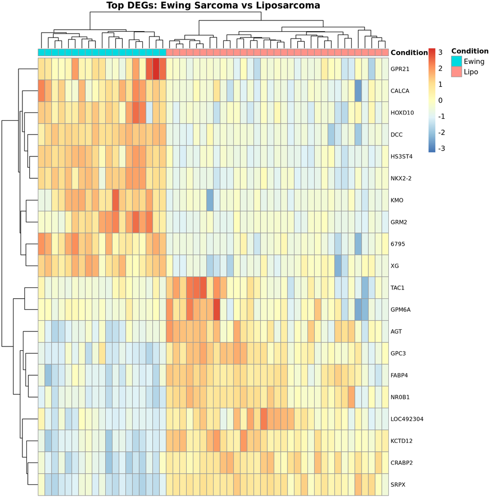

Figure 2: Heatmap of top DEGs

### 3.5 KEGG Pathway Enrichment

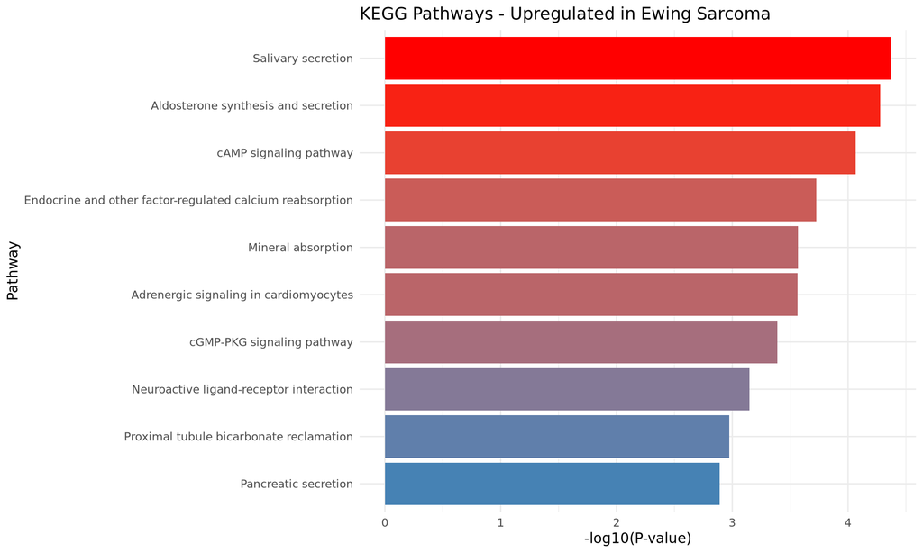

Figure 3: KEGG pathway enrichment

### 3.6 GO Biological Process Enrichment

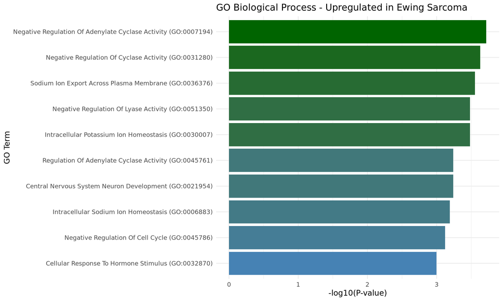

Figure 4: GO biological process enrichment

## 4. Discussion

DESeq2 analysis identified 1443 significant DEGs between Ewing Sarcoma and Liposarcoma. **NKX2-2**, a transcription factor directly regulated by the EWS-FLI1 fusion gene, was among the top upregulated genes in Ewing Sarcoma, consistent with published literature. **FABP4** was the most downregulated gene, reflecting the adipose origin of Liposarcoma.

cAMP signaling pathway enrichment in Ewing Sarcoma upregulated genes is consistent with the known role of EWS-FLI1 in activating cAMP-dependent transcription. These findings provide molecular insights into the distinct biology of these two sarcoma subtypes.

## 5. Conclusion

This DESeq2 analysis identified 1443 significant DEGs distinguishing Ewing Sarcoma from Liposarcoma. NKX2-2 and cAMP signaling emerged as key molecular features of Ewing Sarcoma, providing potential biomarkers and therapeutic targets for further investigation.

## References

1. GSE2553: NCBI GEO (PubMed ID: 16230383)
2. DESeq2: Love MI et al. Genome Biology (2014)
3. enrichR: Kuleshov MV et al. Nucleic Acids Research (2016)
4. R Core Team (2024)